# model

Jan Netík

22 3 2020

```r
library(tidyverse)
library(magrittr)
library(EpiModel)

quiet <- function(x) {
  sink(tempfile())
  on.exit(sink())
  invisible(force(x))
}
```

## assumptions

- consider 12% probability of infection per transmissible act between a susceptible and an infected person
- 5 transmissible acts per day (close co-worker contacts) 18 days to recovery (presume that worker is productive after 18 days)
- intervention begins at day 10 (worker starts to show symptoms and quarantine himself)
- intervention is maximally effective, lowering transmission prob. 10 times
- starting with 49 workers and 1 infected (zero recovered)

```r
sim_days <- 60 # days to simulate for

param <- param.icm(inf.prob = 0.12,
                   act.rate = 5,
                   rec.rate = 1 / 18)

init <- init.icm(s.num = 49,
                 i.num = 1,
                 r.num = 0)

control <- control.icm(
  type = "SIR",
  nsims = 100,
  nsteps = sim_days,
  verbose = T
)

mod <- quiet(icm(param, init, control))
```

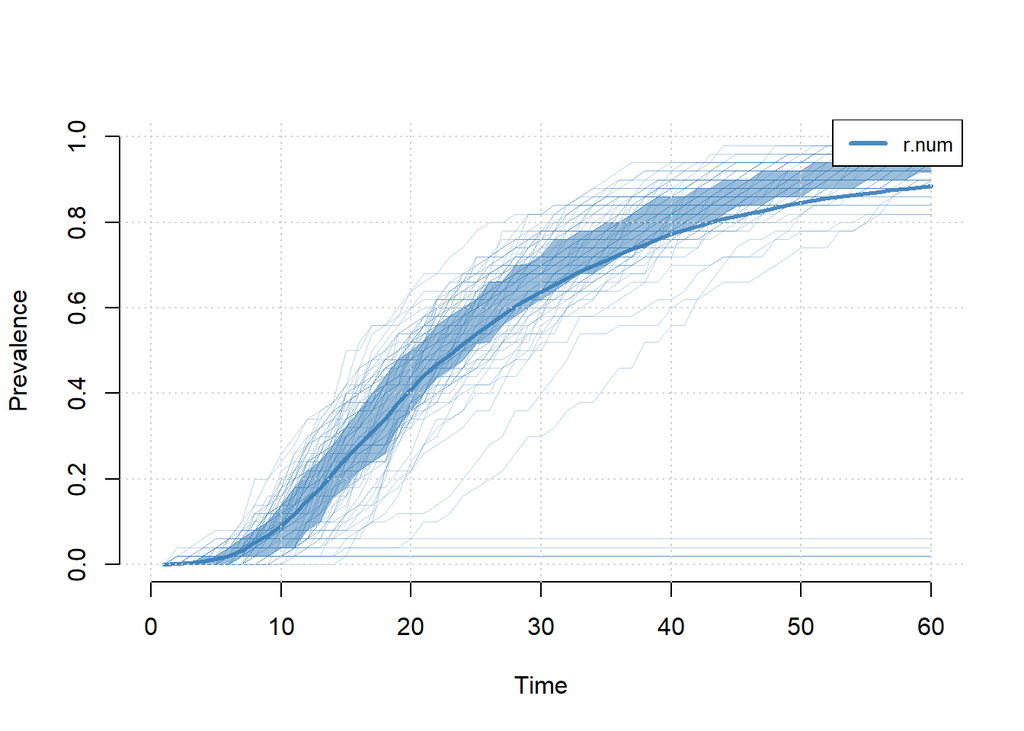

```r
plot(mod, y = "r.num", sim.lines = T, mean.smooth = F, qnts.smooth = F, popfrac = T, grid = T, legend = T)
```

Prevalence of compartments

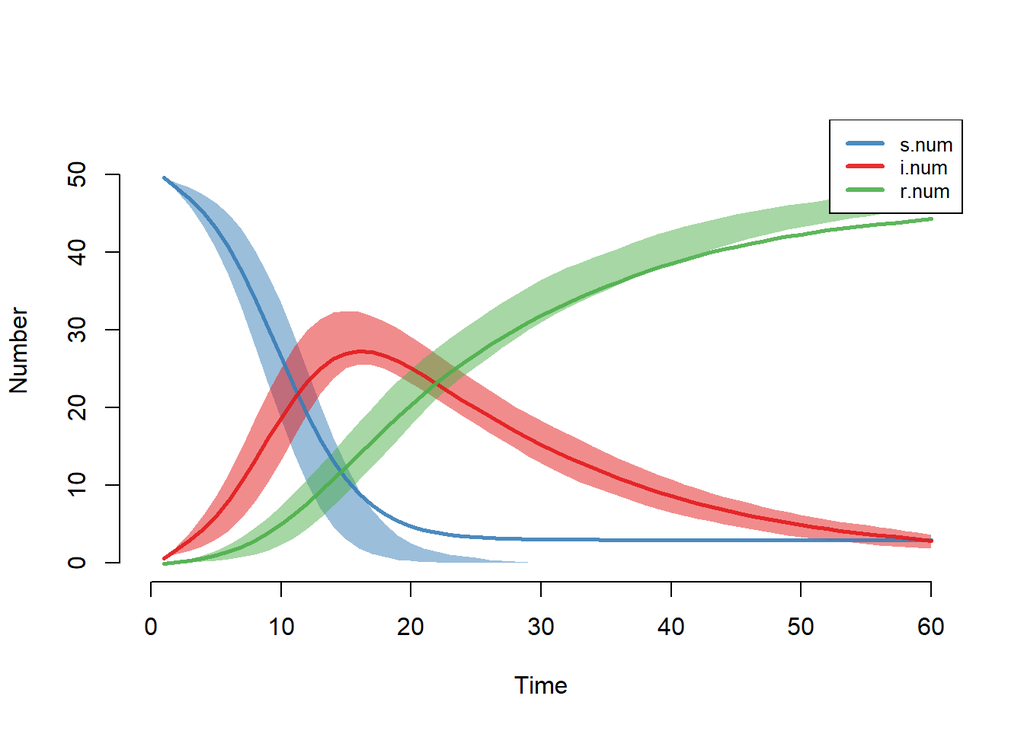

```r
plot(mod, propfrac = T)
```

## Avaiable workers estimation

Assuming susceptible (but not infected) and recovered workers are immediately 100% productive. Note that we are not accounting for 14-day quarantine after remission, but so does not the intervention model – **the difference between those is crucial**.

*Calculate median of simulated estimates per day – get one number per day:*

```r
available_workers <-
  apply(mod$epi$s.num, 1, median) + apply(mod$epi$r.num, 1, median)
```

## Intervention model (inter)

All parameters are the same as in previous model. Intervention (self-quarantine of the worker which starts to show first symptoms) begins on 10th day since the first infected case in a group and it is highly effective.

```r
param_inter <-
  param.icm(
    inf.prob = 0.12,
    act.rate = 5,
    rec.rate = 1 / (18),
    inter.start = 10,
    inter.eff = .9
  )

init_inter <- init.icm(s.num = 49,
                       i.num = 1,
                       r.num = 0)

control_inter <- control.icm(
  type = "SIR",
  nsims = 100,
  nsteps = sim_days,
  verbose = T
)
mod_inter <- quiet(icm(param_inter, init_inter, control_inter))
```

Prevalence of infection

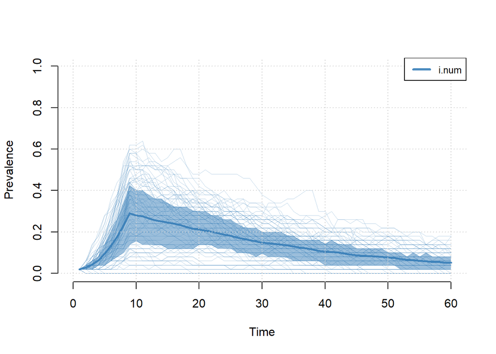

```r
plot(
  mod_inter,
  y = "i.num",
  sim.lines = T,
  mean.smooth = F,
  qnts.smooth = F,
  popfrac = T,
  grid = T,
  legend = T
)
```

Prevalence of compartments

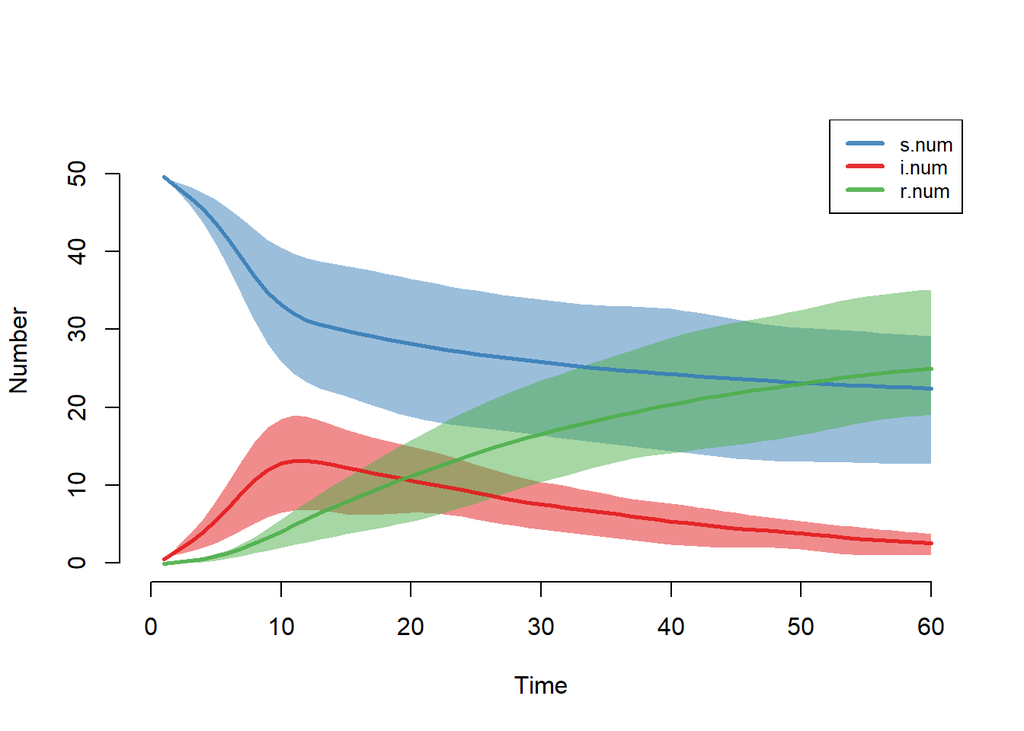

```r
plot(mod_inter, propfrac = T)
```

## Quarantine at 5th day (inter2)

```r
param_inter2 <-
  param.icm(
    inf.prob = 0.12,
    act.rate = 5,
    rec.rate = 1 / (18),
    inter.start = 5,
    inter.eff = .9
  )

init_inter2 <- init.icm(s.num = 49,
                       i.num = 1,
                       r.num = 0)

control_inter2 <- control.icm(
  type = "SIR",
  nsims = 100,
  nsteps = sim_days,
  verbose = T
)
mod_inter2 <- quiet(icm(param_inter2, init_inter2, control_inter2))
```

Prevalence of infection

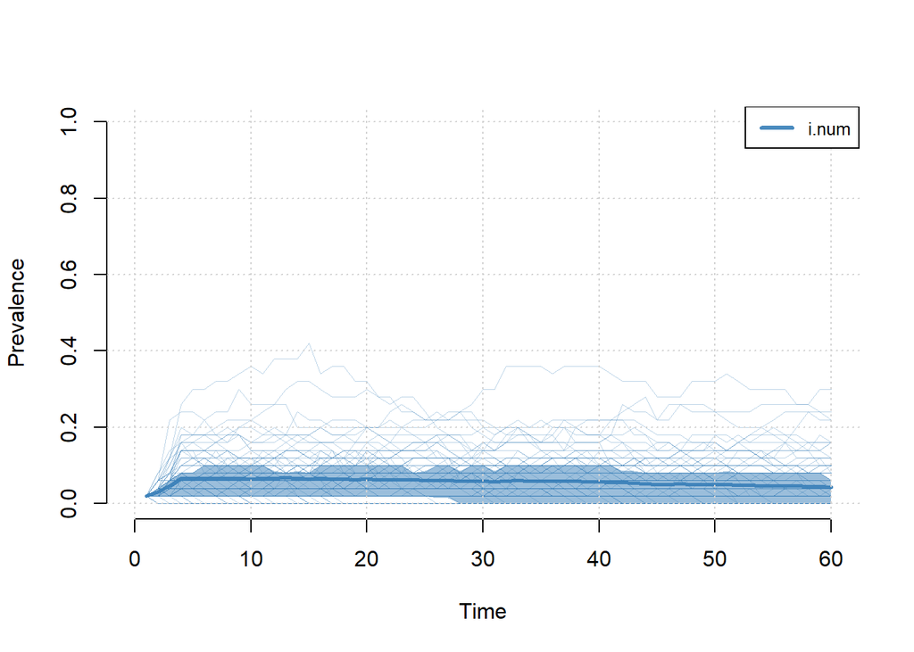

```r
plot(
  mod_inter2,
  y = "i.num",
  sim.lines = T,
  mean.smooth = F,
  qnts.smooth = F,
  popfrac = T,
  grid = T,
  legend = T
)
```

Prevalence of compartments

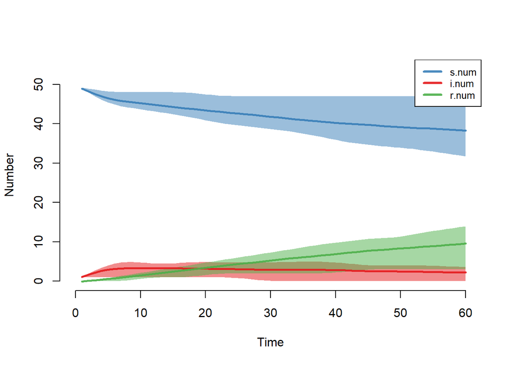

```r
plot(mod_inter2, propfrac = T)
```

```r
available_workers_inter2 <-
  apply(mod_inter2$epi$s.num, 1, median) + apply(mod_inter2$epi$r.num, 1, median)
```

## Invervention benefit

Calculating with productivity per day (34125/30):

```r
available_workers_inter <-
  apply(mod_inter$epi$s.num, 1, median) + apply(mod_inter$epi$r.num, 1, median)

daily_prodictivity <- tibble(
  day = seq(1, sim_days),
  productivity = available_workers * (34125 /
                                        30),
  productivity_inter = available_workers_inter * (34125 /
                                                    30),
  productivity_inter2 = available_workers_inter2 * (34125 /
                                                    30)
)

daily_prodictivity %<>% mutate(saved = productivity_inter - productivity)
```

## Total CZK saved in first month (for 50 people)

Simply sum of difference intervention-nothing productivity

```r
daily_prodictivity$saved[1:30] %>% sum
```

```
## [1] 329875
```

Benefit with 5273700 workers:

```r
(daily_prodictivity$saved[1:30] %>% sum) * (5273700/50)
```

```
## [1] 34793235750
```

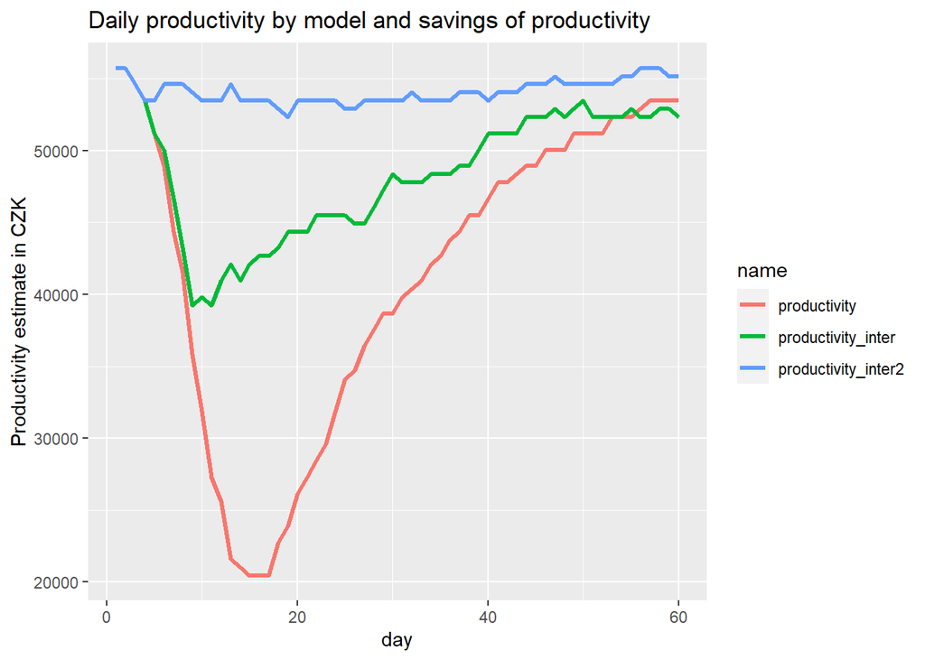

```r
daily_prodictivity %>% pivot_longer(-c(day, saved)) %>%  ggplot(aes(day, value, col= name)) +
  geom_line(size= 1.2) +
  labs(title = "Daily productivity by model and savings of productivity", y = "Productivity estimate in CZK")
```